# Exploring The Phenomonon of ‘Food Deserts’ In The Contiguous United States

Jude Lobo

```r
#CodeBook
codebook <- read.csv("food_access_variable_lookup.csv")

#Loading in Food Desert Data and Preliminary Data Cleaning Steps
food <- read.csv("food_access_research_atlas.csv")
food <- rename(food, NAME = County)

#The food dataframe currently contains 72864 observations, much too unwieldy for our purposes.
#In the next lines of code, the food dataframe is grouped by county name and then split
#into smaller tibbles according to their county name.
food <- food %>% group_by(NAME)
food <-split(food, food$NAME)


#A dummy dataframe, 'totalpop' is created. It will house the cleaned data from the 'food' dataframe relevant to our analysis.
totalpop <- data.frame(0,0)
totalpop$NAME <- NA
totalpop$Pop <- NA
totalpop <- totalpop[,-c(1,2)]
totalpop[nrow(totalpop) + 1837 , ] <- NA

#For each of the smaller split tibbles created previously, the following for loop will extract the title of that tibbles and store it in the "NAME" column,as this is the name of the county. It will then compute the total number of individuals in that county that live within a food desert by calling a sum() function to the tibble column 'lapop10'. This value will be assigned to the previously extracted 'NAME' county name. This for loop will run 1837 times, as there are 1837 split tibbles that it must extract data from.
for (i in 1:1837){
  totalpop$NAME[[i]] <- food[[i]][["NAME"]][1]
  totalpop$Pop[[i]] <- sum(food[[i]][["lapop10"]])
}

#Any NA values are now omitted
totalpop <- na.omit(totalpop)

#Spatial Data (Map of US Counties) is loaded
shp <- readOGR(dsn = './shp', layer = "UScounties")

#The Spatial data is merged with the totalpop dataframe which contains our cleaned food desert data. This will enable the data to be spatially visualized via a map.
joined <- merge(shp, totalpop, by = 'NAME', duplicateGeoms = TRUE)

#Some NA values have appeared after the join. These values cannot be directly omitted as they will cause the eventual spatial visualization to return errors. Thus, the next for loop will seek these NA values out, and input '0' in place of the NA. This will not skew our data, as we are only interested in the counties WITH food desert populations, not counties with ZERO food desert populations. For our purposes, these values are still 'NA' as we are not analyzing them.

for (i in 1:3141){
  if (is.na(joined@data['Pop'][[1]][[i]]) == TRUE){
    joined@data['Pop'][[1]][[i]] = 0

  }
}
```

```r
#Data set containing the total population of each county
countypop <- read.csv("county_complete.csv")

#Data cleaning of the county name column, as many naming variations exist.
countypop <- countypop %>% mutate(NAME = str_remove_all(NAME, "County"))
countypop <- countypop %>% mutate(NAME = str_remove_all(NAME, "Census Area"))
countypop <- countypop %>% mutate(NAME = str_remove_all(NAME, "Borough/municipality"))
countypop <- countypop %>% mutate(NAME = str_remove_all(NAME, "Borough"))
countypop <- countypop %>% mutate(NAME = str_remove_all(NAME, "/city"))

#blank space removed from the count name column
for (i in 1:3142){
  countypop[i,2] = trimws(countypop[i,2])
}

#dataset containing food desert population count merged with dataset containing total population count for each county
popPerc <- merge(totalpop, countypop, by = "NAME")

#Column that will contain the total percentage of each county populace that resides within a food desert is created. Calculation completed in the following for loops.
popPerc$TotPop <- NA

for (i in 1:3027){
  popPerc[i,5] <- popPerc[i,2]/popPerc[i,4]
}

for (i in 1:3027){
  ifelse(popPerc[i,5] > 1, popPerc[i,5] <- NA, popPerc[i,5] <- popPerc[i,5])
}

#NA's dropped
popPerc <- drop_na(popPerc)


totalpop <- popPerc
```

### What is a Food Desert?

According to the US Census, a Food desert is defined by a geographic area in which organic foods are not easily accessible to the populace living inside such an area. Formally defined, the threshold of a “Food Desert” is met when a population has to travel **more than 1 Mile in Urban Areas** to attain fresh produce, and **more than 10 Miles in Rural Areas** to attain fresh produce (Ver Ploeg 205).

To say one lives within a food desert is not to say one lives without food. In the absence of fresh produce, such as fruits and vegetables, those who reside within a food desert find their diets to be primarily made up of non-perishable goods high in preservatives. While consuming such foods are by no means a death sentence, prolonged consumption of such foods may lead one to develop a number of chronic illnesses later on in life, not least due to the prolonged lack of vital organic nutrients those who live in food deserts subject their bodies to (Sparks 1715).

It is often said that one is a reflection of one’s environment. In such a way, one should care about the phenomenon of food deserts as they effect the lives of those who reside inside of them in unique, profound, and often hidden ways. The findings of this exploration will undoubtedly be of use to demographers and all those interested in health and social policy, as it may provide useful insights on how to improve the quality of life of those who reside within food deserts, or how one may eliminate food deserts all together.

### Data

This analysis utilizes data provided by the US Census. As a data source, the US Census can be trusted for two main reasons. Firstly, the US Census is subject to periodic audits due to its reliance on government funding (taxes) to carry out its work. As the data from the US Census often goes on to inform key democratic processes such as the creation/revision of congressional districts, these audits are taken very seriously. Secondly, the US Census *itself* releases information on how trustworthy its data sets are, based on a number of metrics such as how many valid respondents had actually responded, and the limitations of its data collection efforts (U.S Census). Such candor goes a long way to ensure one’s trust in the US Census, as one knows exactly what one can and *cannot hope* expect to gain when interpreting a US Census data set.

Through data provided by the US Census, the phenomenon of a “food desert” is quantified by measuring the distance those in a geographic area have to travel to get to a supermarket/distribution center where organic foods are available. The Unit of Analysis that will be employed is that of the **county**. This is due to the fact that “Census Tracts”, the unit of analysis in which food desert data is released by the US Census, is *far* too small a unit to visualize with any success. For similar reasons, “States” is not an appropriate unit of analysis as it is far to large to capture the subtle permutations that may exist in the food desert data.

The ethical issues that may have arose during the collection of the data, and the specific data sets themselves, will be described in detail in the discussion following each relevant visualization.

### Where do Food Deserts occur?

##### **Figure 1**

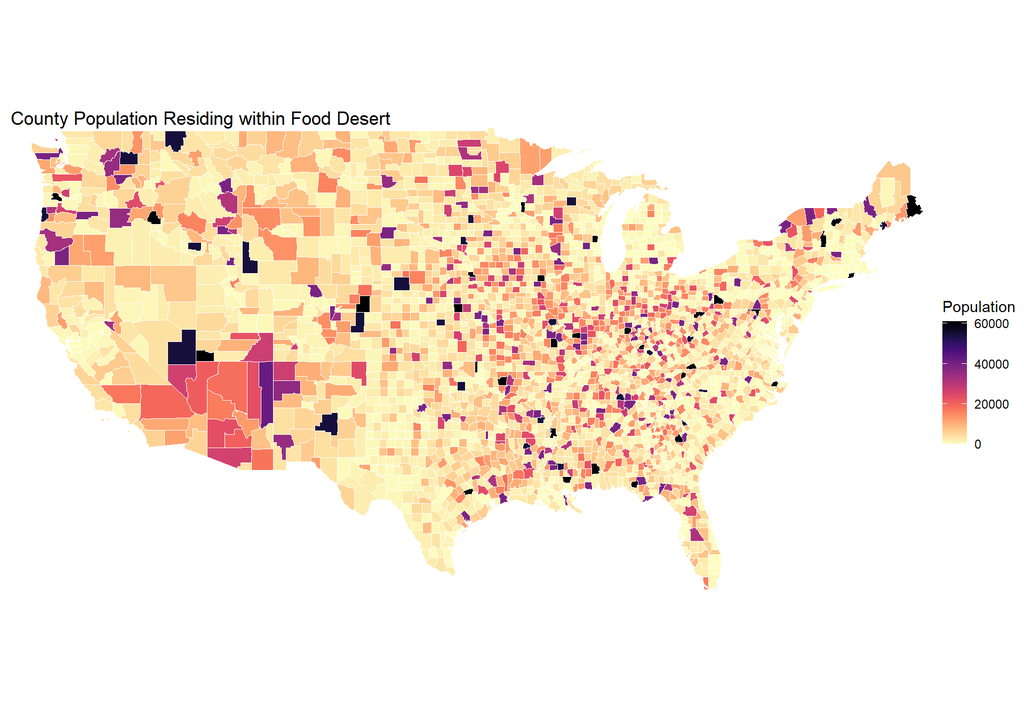

```r
#Map Visualization
joined2 <- st_as_sf(joined)
map <- ggplot(joined2) + geom_sf(aes(fill = Pop), colour = "white") + xlim(-124, -69) + ylim(25, 48) + scale_fill_viridis(option="magma", direction = -1) + ggtitle("  County Population Residing within Food Desert")+
  labs(fill = "Population  ")

map + theme_void()
```

Within **Figure 1**, one will find a map of the contiguous United States, colored to represent counties by the absolute number of their population that resides within a food desert. For this preliminary visualization, representing a county’s food desert population as a percentage of the entire population was purposely decided against, as counties with larger populations may report an artificially low food desert population percentage, while harboring some of the highest absolute number of food desert populations. This preliminary visualization aims at providing a rough overview of the actual size and distribution of food desert populations in the contiguous United States, free from as much distortion as possible.

One may note that while virtually all regions of the United States are be-speckled with *some* counties with a high food desert population, the South West of the United States appears to be particularly inundated with counties that report high food desert populations, as a great many counties in that region are displayed in darker colors. This region is renowned for its vast expanses of geographic deserts such as the Sonoran, Great Basin and Chihuahua Deserts. Perhaps these geographic realities have informed the spatial distribution of living spaces in this region? Perhaps, due to the harsh desert climate, those who live within the region live spread out along few instances of infrastructure in the region. This could render the entire region not only as Rural, but a Rural food desert due to how sparse the population is.

The effect Rural and Urban demographic distributions have on the phenomenon of Food Deserts will be explored in detail in the next visualization (**Figure 2**).

In terms of ethical considerations for **Figure 1**, there is not much that one may concern oneself with. The data set that informed the creation of **Figure 1** was created by the US Census, subject to all of the checks and balances mentioned previously. The data set itself was created by measuring the distance each household within a census tract was to a commercial source of organic food, with the ensuing following amalgamation of this data to the county level completed manually. Whether a household or a person living in a census tract met the threshold for residing within a food desert was simply recorded as a *Yes* or a **No**, with no information specific to any individual person entered into the data set. Thus, the privacy of all those this data set concerned itself with was respected, with there being virtually no risk of de-anonymization.

##### **Figure 2**

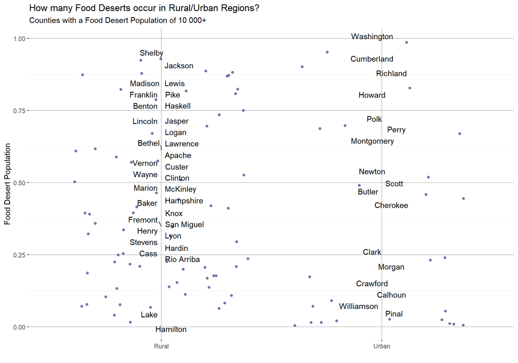

```r
#Jitter Plot Visualized
p <- ggplot(ujoined, aes(x = UrbanRural, y = TotPop, label = NAME)) +
  geom_jitter(color = "darkslateblue", alpha = 0.7) + ggtitle("How many Food Deserts occur in Rural/Urban Regions?", subtitle = "Counties with a Food Desert Population of 10 000+") + ylab('Food Desert Population') + xlab('') + theme(panel.grid.major = element_line(colour = "grey"))

#Jitter plot labled
p + geom_text_repel(aes(label = NAME))
```

In **Figure 2** above, one can find a jitter plot of counties that are home to a food desert population of more than 10 000 people. This jitter plot is divided between “Rural” and “Urban” classifications on the X-Axis (as decided by the US Census), with the percentage of the county population that resides within a food desert displayed on the jitter plot’s y-axis.

There are a number of interesting inferences to be made from this jitter plot. To begin, one may wonder, **how is it that so many urban counties are such that large percentages of their population do not have access to organic food?** This seems to be the reality for a great many urban counties, which in itself seems to fly in the face of the definition of “urban”. It seems to be common sense that food distributors gravitate towards geographic areas where a large number of people are concentrated (i.e.urban areas), as this naturally signals that there is a fair amount of profit to be extracted from such a group. **What is it about these urban counties that seem to render them as exceptions to this rule?

Concomitant with our discussion on **Figure 1**, it does seem that a large portion of these Urban Counties, such as “Washington County, Utah”, “Clark County, Nevada”, and a great many Rural Counties, such as “Apache County, Arizona” and “McKinley County, New Mexico” are located in the South Western Region of the United States. Upon taking a closer look as “Washington County, Utah”, a county that despite its Urban classification, reports nearly 100% of its population living in an Food Desert, one may discover that this county is home to the Paiute Indian Reservation, a sprawling reservation on the edge of Washington County that a majority of the county’s residents either reside inside of or on the edge of. The same may be found for “Clark County, Nevada” as well as the Rural Counties of “Apache County, Arizona” and “McKinley County, New Mexico”, among other counties.

This connection between the phenomenon of food deserts in the South Western United States and the presence of indigenous reserves will be explored in greater detail in **Figure 3** and **Figure 4**.

With respect to any ethical concerns one may have, one must note that **Figure 2** utilizes the same data set that delineates food desert population by county, that **Figure 1** utilized. **Figure 2** has simply reformatted the same data so that visual emphasis is placed upon the Urban/Rural demographic county classification. As such, the same ethical reservations for **Figure 1** (or lack thereof) may apply to **Figure 2**.

The additional information presented in **Figure 2** of Urban/Rural classification does not in itself pose an ethical concern, as this information is already widely available, and is applicable to many counties. One would be hard pressed to find a way to abuse this information, as not only is it not specific to any person, but this classification in itself is not specific to any county as well. For example, while 2 counties may be classified as “Urban”, they may not be urbanized to the same *degree*, despite sharing the same classification.

##### **Figure 3**

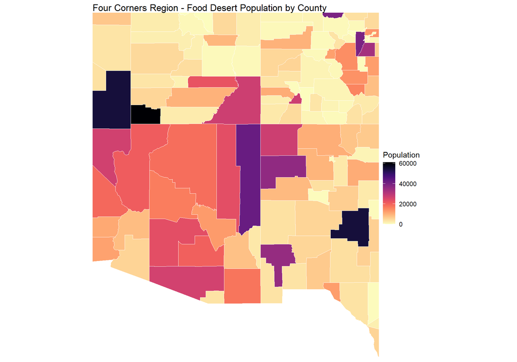

```r
#Subset of Figure 1 is cut and vizualized
map <- ggplot(joined2) + geom_sf(aes(fill = Pop), colour = "white") + xlim(-115, -105) + ylim(30, 40) + scale_fill_viridis(option="magma", direction = -1) + ggtitle("Four Corners Region - Food Desert Population by County")+
  labs(fill = "Population  ")


map + theme_void()
```

```r
#Counties of interest are identified based plurality of Native Americans, identified by their FIPS code and placed within the dataframe df.
vec  <- c(49037,04001,04017,04005,35045,35031,35006,35043)

df <- data.frame(
  fips = vec,
  values = c(1,1,1,1,1,1,1,1)
)


#Four corners region is visualized with selected counties colored in.
fourcor <- plot_usmap(include = c("AZ","NM","UT","CO"),data = df, labels = TRUE,label_color = 'red', show.legend = FALSE)  +scale_fill_continuous(low="darkslateblue", high="darkslateblue",
                       guide="colorbar",na.value="cornsilk") +
  geom_polygon(data = usmapdata::us_map(include = c("AZ","NM","UT","CO")),
                 aes(x, y, group = group), fill = NA, size = 1, color = "black") + ggtitle("Four Corners Region: Counties with a Plurality of Native Americans") + theme(plot.title = element_text(hjust = 0.5))



#Counties of interest (+10 000 food desert populations) are identified and stored within the dataframe df1.
vec1  <- c(49037,04001,04017,04005,35045,35031,35006,35043,04019,04023,04013,49055,35017,35027)

df1 <- data.frame(
  fips = vec1,
  values = c(1,1,1,1,1,1,1,1,1,1,1,1,1,1)
)


#Expanded four corners visualization is visualized to include new counties with +10 000 food desert populations
fooddes <- plot_usmap(include = c("AZ","NM","UT","CO"),data = df1, labels = TRUE, label_color = 'red', show.legend = FALSE)  +scale_fill_continuous(low="darkslateblue", high="darkslateblue",
                       guide="colorbar",na.value="cornsilk") +
  geom_polygon(data = usmapdata::us_map(include = c("AZ","NM","UT","CO")),
                 aes(x, y, group = group), fill = NA, size = 1, color = "black") + ggtitle("Four Corners Region: Counties with +10 000 Food Desert Populace") + theme(plot.title = element_text(hjust = 0.5))
```

Within **Figure 3**, one will find a refined plot of **Figure 1**, zoomed into the South West region of the United States, particularly, the ‘Four Corners’ Region. As can be seen, the counties that constitute this region are home to a very large number of those who reside within food deserts, as can be inferred from the many dark shades that color the map. As the only changes that have been made to this visualization are aesthetic in nature, the same ethical consideration for **Figure 1** apply to **Figure 3**.

Noting that a great many counties in this region are home to a large number of those who reside within food deserts, one may now test the claim formulated in the discussion of **Figure 2** by directly visualizing whether these counties also harbor reservations with large indigenous populations, identified manually using US Census data. This analysis will be carried out in **Figure 4**.

##### **Figure 4**

```r
#GIF
fooddes
```

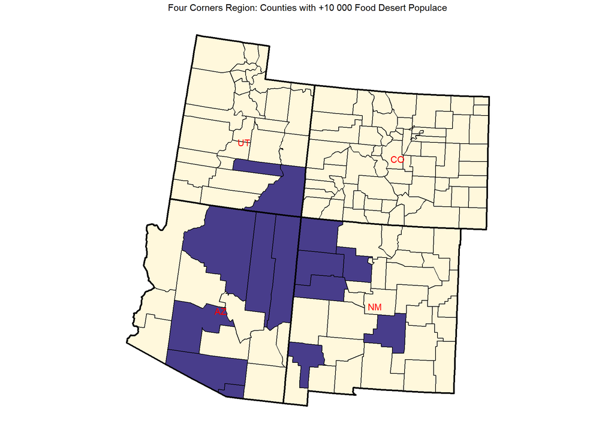

```r
fourcor
```

[output not shown]

Within **Figure 4**’s GIF, one will find a visual comparison between counties that harbor a food desert population that is greater than 10 000 individuals, and counties that are home to a plurality of those that live on an Indian Reserve (i.e. those that live on an Indian Reserve (and are of Native American Heritage) constitute that largest ethnic/social group in the entire county).

One will find that the results are quite clear, in that there is a clear correlation between counties with a large food desert population and counties where a large portion of their populace resides on a reserve. This makes sense, as Native American Reserves, being sub-sovereign entities under the semi-autonomous control of the resident Native American Tribe, have control over what companies are allowed to do business within their territory (Kewenvoyouma par.12). Thus, if a supermarket wants to expand into reserve territory, they need to hammer out separate agreements with local the Native American leadership before they can successfully start selling their wares. As even the most populace Native American reserves are home to only a few tens of thousands of people, many would-be distributors of organic food bypass these areas entirely, as they do not see the added legal and administrative costs of expansion as worth it for the opportunity to sell to only a few thousand more individuals. This results in vast regions of the South West United States, as visualized in **Figure 3** and **Figure 4**, becoming food deserts.

There are a great many ethical concerns to be considered both in the process of attaining and the process of interpreting the data utilized to create **Figure 4**. To start, while I was able to determine which counties contained a plurality of those of Native American descent, I was not able to determine the exact *ethnicities* of the groups in question, other than the fact that those in question were all of indigenous descent. This shortcoming of the US Census, where this data was attained, was quite shocking and very telling of the level of care and attention afforded to Native Americans in the United States. Just as the US Census records those of German, British, Italian, French, Greek etc. descent under the wider umbrella of the classification of “White”, so too is it only appropriate to record whether one is (for example) of Chicasaw, Colville, Houma, Ute etc. under the wider classification of “Native American/Indigenous”, as each of these subgroups have their own distinct language and culture worthy of its own statistic at the very least, just as is afforded to other heritages. When many of these cultures are already faced with extinction, these small steps are the least one can do to ensure these unique cultures, heritages and traditions do not fall into obscurity.

Thus, to remedy this egregious ethical transgression, uncovered at the data collection/attainment stage, one can be mindful at how one interprets this data. When cleaning this data, or aiming to make an inference on this data or a visualization based upon this data, one must be mindful that they are interacting with **many** unique cultures, as opposed to a Native American monolith. These cultures deserve policies that are unique to them, policies that the US Census is not completely capable of adequately informing. Thus, while the US Census data was adequate for the purposes of visualizing **Figure 4**, as we were only concerned with those who claimed *any* Native American descent, this data is not suitable for scenarios which require a more focused approach, nor is its use in such a case ethical.

Proceeding on from this topic, one will remember from **Figure 1** and **Figure 2** that there are some counties that contain a high number of individuals who reside within food deserts in other parts of the United States, such as the Mid-West.However, there are no major Native American reserves in these areas. What could be the cause of these specific food deserts? This question will be the subject of analysis of **Figure 5** and **Figure 6**.

##### **Figure 5**

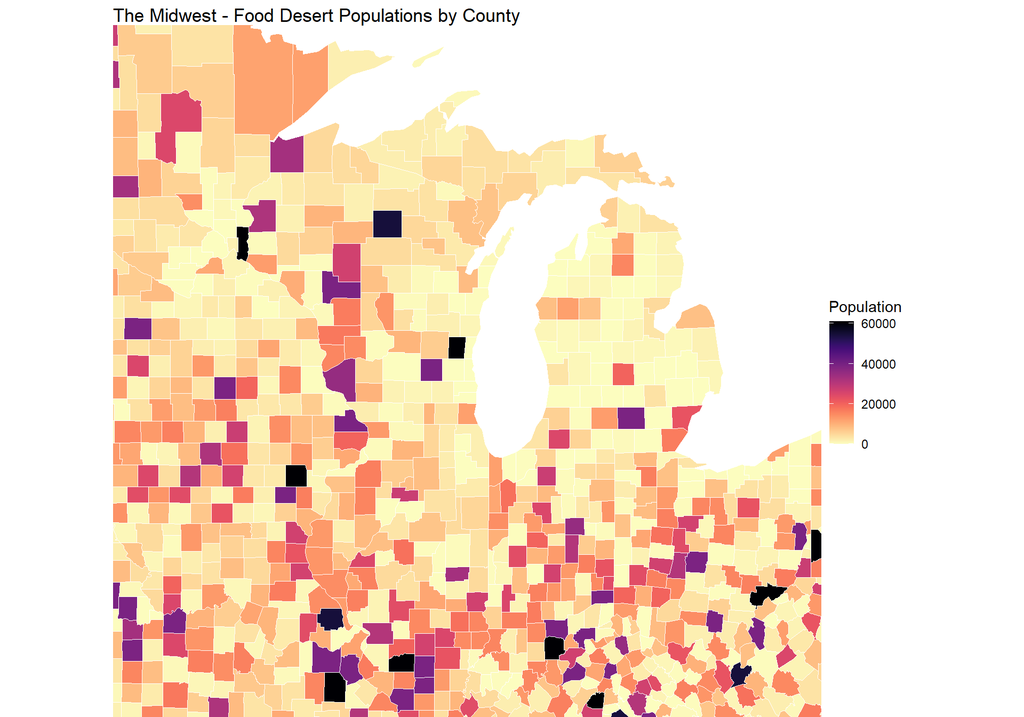

```r
#Refined plot of Figure 1 is visualized
ggplot(joined2) + geom_sf(aes(fill = Pop), colour = "white") + xlim(-95, -81) + ylim(38, 48) + scale_fill_viridis(option="magma", direction = -1)  + geom_polygon(data = usmapdata::us_map(include = c("MN","IA","MO","IL","WI",'IN','OH','MI')),
                 aes(x, y, group = group), fill = NA, size = 1, color = "black") + ggtitle("The Midwest - Food Desert Populations by County") + theme(plot.title = element_text(hjust = 0.85)) +
  labs(fill = "Population  ") +  theme_void()
```

In **Figure 5** above, one will find a refined section of **Figure 1**, depicting the Mid-West Region of the United States. **One has reason to be immediately suspicious of the occurrence of Food Deserts in the Mid-West**, as this region of the United States is quite developed, with even the rural parts of the Mid-West only a short drive away from civilization, and by extension, many sources of organic food.

Unlike **Figure 3**, one will note that vast regions of each state, and multiple connected counties in succession, **do not** all exhibit high food desert populations. Rather, counties that exhibit the highest food desert populations are rather isolated. This immediately indicates that these food deserts are not the result of exogenous land and legal agreements that have been applied to vast swathes of land, as was the case in **Figure 3** and **Figure 4**. Rather, the counties in **Figure 5** that exhibit a high food desert population may do so due to factors *inside* the county.

Looking at **Figure 2** and **Figure 5**, one may note that some counties in the Mid-West that report high food desert populations also happen to be home to some of the largest population centers of their entire state (i.e. Franklin County, Ohio, home to the Capital City of Ohio: Columbus, or Waukesha County, Wisconsin, home to the third largest city in Wisconsin: Waukesha). Perhaps the data visualized in **Figure 5** is spurious, in that instead of true food deserts being visualized, those counties that exhibit high food desert populations are just home to high populations **in general**, such that despite the county having a fair amount of access to organic food, the few outlier individuals (i.e. a few thousand amidst a population of 1 million +) amongst the exceptionally large population rank the county in question amongst the foremost food desert county’s.

To test this hypothesis, **Figure 6** will compare the largest food deserts of **Figure 5** to the top 3 most populace counties in each state.

As the only changes that have been made to this visualization are aesthetic in nature, the same ethical considerations for **Figure 1** apply to **Figure 5**.

```r
#Counties manually selected by FIPS code according to the previous visualization, stored within df1.
vec1  <- c(39167,39049,26075,27095,27021,27021,27163,55069,55133,17189)

df1 <- data.frame(
  fips = vec1,
  values = c(1,1,1,1,1,1,1,1,1,1)
)

#Midwest Food Desert Counties are visualized
fooddes1 <- plot_usmap(include = c("MI","IA","IL",'WI','MN','IN','OH'),data = df1, labels = TRUE, label_color = "red", show.legend = FALSE)  +scale_fill_continuous(low="darkslateblue", high="darkslateblue",
                       guide="colorbar",na.value="cornsilk") +
  geom_polygon(data = usmapdata::us_map(include = c("MI","IA","IL",'WI','MN','IN','OH')),
                 aes(x, y, group = group), fill = NA, size = 1, color = "black") + ggtitle("Midwest Region: Counties with +10 000 Food Desert Populace") + theme(plot.title = element_text(hjust = 0.5))




# 3 Most populace counties in each state are selected
vec2  <- c(39167,39035,39061,26163,26125,26099,27123,27037,27163,55079,55025,55133,17031,17089,17111)

df9 <- data.frame(
  fips = vec2,
  values = c(1,1,1,1,1,1,1,1,1,1,1,1,1,1,1)
)

#3 most populace counties in each midwestern state are visualized
populace <- plot_usmap(include = c("MI","IA","IL",'WI','MN','IN','OH'),data = df9, labels = TRUE, label_color = "red", show.legend = FALSE)  +scale_fill_continuous(low="darkslateblue", high="darkslateblue",
                       guide="colorbar",na.value="cornsilk") +
  geom_polygon(data = usmapdata::us_map(include = c("MI","IA","IL",'WI','MN','IN','OH')),
                 aes(x, y, group = group), fill = NA, size = 1, color = "black") + ggtitle("Midwest Region: Top 3 Most Populace Counties in Selected States") + theme(plot.title = element_text(hjust = 0.5))
```

##### **Figure 6**

```r
#GIF
fooddes1
```

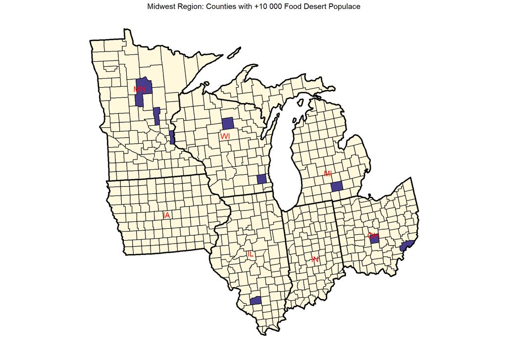

```r
populace
```

[output not shown]

Within **Figure 6**’s GIF, one will find a visual comparison between counties that harbor a food desert population that is greater than 10 000 individuals, and the top 3 most populace counties in each state with at least one county with a food desert population above 10 000 (i.e. Iowa and Indiana are not used because they contain no counties with a food desert population above 10 000).

That these counties are left un-explained by this method **still** does not rule out the potentiality of these food desert counties being distorted by large population centers around them. For example, research reveals that Mille Lacs County is included in the Minneapolis-St. Paul-Bloomington statistical area, due to the high integration of infrastructure that exists between these geographic areas. Thus, even though residents within Mille Lacs county meet the geographic definition of living inside a food desert, in reality it is not cumbersome at all for residents to travel to the next town, or even the next county, to attain organic foods due to how integrated transportation infrastructure is. The same phenomenon can be argued for many of the remaining unexplained food desert areas, such as Washington County, Ohio, which is integrated into the Parkersburg-Marietta-Vienna Statistical Area.

In terms of data, this finding demonstrates how our Unit of Analysis, (the county), can hinder data exploration, as the inferences and conclusions uncovered in the previous paragraph would not have been possible if one were to stick rigidly at the county level, despite the same data set and unit of analysis serving all previous figures to great effect.

Ethically speaking, similar to **Figure 2**, one would be hard pressed to uncover any way to abuse the data introduced in **Figure 6**, such as the counties that are most populous in each state, and statistical areas, as this information is already widely available out in the physical world. “Population Centers” are phenomena that one can experience for oneself, and so are not novel information revealed exclusivity by this data set. Furthermore, this information was collected and presented by the US Census (and **Figure 6**) in a manner that was qualitatively neutral. Thus, if any ethical problems exist in the information uncovered by this data set and its usage in **Figure 6**’s visualization, such an ethical problem is certainly not novel or unique to this dataset in particular.

```r
#A dataset containing the median household income of each county is loaded
income <- read.csv("HI.csv")

#The dataset column containing the county name is changed, so that it can be easily joined with the 'totalpop' dataset later.
income <- income %>%
  rename("NAME" = "Area_name")

#There are a few values that are simply blank. The next lines of code input an NA value for all blank values in the dataset, which are then removed.
income <- income %>% mutate_all(na_if,"")
income <-  na.omit(income)

#The 'NAME' column of the 'income' dataset contains county names with many additional identifiers, such as 'County' or 'Census Area' after the county name. These extra identifiers preclude this column from being easily joined with its counterpart in the 'totalpop' dataset. The next few lines of code remove these identifiers.
income <- income %>% mutate(NAME = str_remove_all(NAME, "County"))
income <- income %>% mutate(NAME = str_remove_all(NAME, "Census Area"))
income <- income %>% mutate(NAME = str_remove_all(NAME, "Borough/municipality"))
income <- income %>% mutate(NAME = str_remove_all(NAME, "Borough"))
income <- income %>% mutate(NAME = str_remove_all(NAME, "/city"))

#The "NAME" column in the income dataset also contains the total median household income of each state, before listing the median household income of each county within the state. These aggregate values are interspersed throughout the income dataset. The following for loop checks to see whether each value of the 'NAME' column is a STATE name by comparing it against the list 'states'. If it is, the entire row is removed from the income dataset.
states <- list('Alabama', 'Alaska', 'American Samoa', 'Arizona', 'Arkansas', 'California', 'Colorado', 'Connecticut', 'Delaware', 'District of Columbia', 'Florida', 'Georgia', 'Guam', 'Hawaii', 'Idaho', 'Illinois', 'Indiana', 'Iowa', 'Kansas', 'Kentucky', 'Louisiana', 'Maine', 'Maryland', 'Massachusetts', 'Michigan', 'Minnesota', 'Minor Outlying Islands', 'Mississippi', 'Missouri', 'Montana', 'Nebraska', 'Nevada', 'New Hampshire', 'New Jersey', 'New Mexico', 'New York', 'North Carolina', 'North Dakota', 'Northern Mariana Islands', 'Ohio', 'Oklahoma', 'Oregon', 'Pennsylvania', 'Puerto Rico', 'Rhode Island', 'South Carolina', 'South Dakota', 'Tennessee', 'Texas', 'U.S. Virgin Islands', 'Utah', 'Vermont', 'Virginia', 'Washington', 'West Virginia', 'Wisconsin', 'Wyoming')

for (i in 1:3193){
  if (income[i,1] %in% states){
    income <- income[-i,]
  }
}

#Each county name in the 'NAME' column of the income dataset still contains a state identifier after its name. For example, 'Arlington" is listed as 'Arlington, VA ". We do not need anything after and including the comma, as these are not part of the county name. The following for loop iterates throughout the entire 'NAME' column of the income dataset, and deletes the last 5 characters of the string, so that only the true county name is left.
for (i in 1:3193){
  income[i,][1] = substring(income[i,][1], 1, nchar(income[i,][1])-5)
}


#the income dataset is now merged with the totalpop dataset, along the "NAME" column.
ijoined <- merge(income, totalpop, by = 'NAME', duplicateGeoms = TRUE)

#The Median_Household_Income values are inputted as strings instead of numbers, with a comma included as a thousands place value separator. The comma is removed in the next lines of code, and the column is translated from a charchter to a numeric datatype.
ijoined$Median_Household_Income <- as.numeric(gsub(",", "", ijoined$Median_Household_Income))

ijoined <- ijoined %>% distinct(NAME, state, .keep_all = TRUE)

ijoined <- ijoined[ijoined$Pop >= 10000,]


summary(lm(TotPop ~ Median_Household_Income, data = ijoined))#r squared
```

### Social and Economic Determinants of Food Deserts: Income and Transportation

As was suggested in the discussion of **Figure 6** and integrated transportation infrastructure, many other factors other than that of location and distance have the potential to explain the cause and relative severity of a Food Desert. The following two figures, **Figure 7** and **Figure 8**, will explore the effects of Income and Transportation on Food Deserts.

##### **Figure 7**

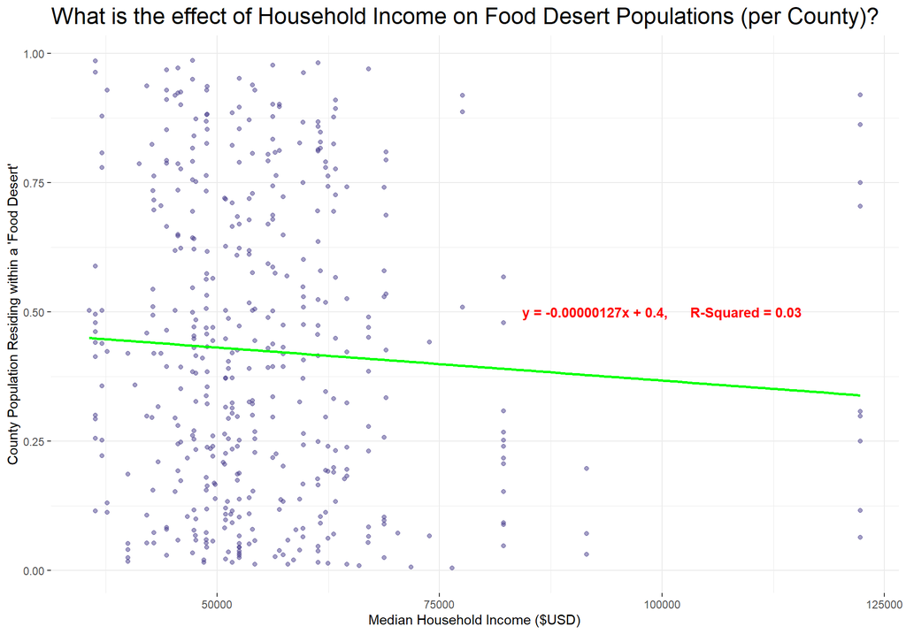

```r
# A scatterplot and regression line of the joined dataset is plotted.
ggplot(ijoined, aes(x=Median_Household_Income, y=TotPop)) + geom_point(color = "darkslateblue", alpha = 0.5) + geom_smooth(method='lm', color = "green", se = FALSE) + ylab("County Population Residing within a 'Food Desert'") + xlab('Median Household Income ($USD)') + ggtitle("What is the effect of Household Income on Food Desert Populations (per County)?") + theme(plot.title = element_text(size=18)) + annotate("text", x = 100000, y = 0.5, label = "y = -0.00000127x + 0.4,      R-Squared = 0.03", color = "red",fontface =2)
```

Depicted within **Figure 7**, one will find a scatter-plot and regression line chart, depicting the relationship between Median Household Income ($USD) per County on the X-Axis, and the percentage of a county’s population that lives within a food desert, depicted on the Y-Axis.

Substantively speaking, this linear regression line tells us that Median Household Income of a county is able to tell us **NOTHING** about the percentage of a county’s populace that lives within a food desert. Thus, if one is looking to explain why food desert’s occur, median household income is not a key determinant. Although one may at first believe that supermarkets and other organic food distributors avoid poorer areas because there is less profit to extract from the populace, rendering those areas as ‘food deserts’, **Figure 7** clearly proves this belief to be mistaken. The phenomenon of food deserts has little, if anything, to do with income.

In general, one should always exhibit caution, empathy and sincerity when dealing with income data, as it is easy for one to extrapolate character judgement from such data to attempt explain social scientific phenomena, when such judgements are in fact wholly uncalled for. For example, one may wrongly suggest, based upon **Figure 7** that the poor are more likely to reside in food deserts due to general laziness, or an unwillingness to help themselves. Not only are such conclusions never reflected within income data alone, but they represent poor social science practice in general, as such conclusions miss the inherent complexity that accompanies the interpretation of such data.

```r
#A dataset containing the total number of cars in each county is loaded, subsetted to only include the county name and the total no. of cars in that county.
cars <- read.csv("cardata.csv")
cars <- cars[2:3]

#column names are renamed to more manageable names
cars <- cars %>%
  rename("NAME" = "Geographic.Area.Name", "TotCars" = "Estimate..Total")

#similar to the previous dataset, additional county name identifiers are edited out of the dataset.
cars <- cars %>% mutate(NAME = str_remove_all(NAME, "County"))
cars <- cars %>% mutate(NAME = str_remove_all(NAME, "Census Area"))
cars <- cars %>% mutate(NAME = str_remove_all(NAME, "Borough/municipality"))
cars <- cars %>% mutate(NAME = str_remove_all(NAME, "Borough"))
cars <- cars %>% mutate(NAME = str_remove_all(NAME, "/city"))

#Each county name also contains its state location (i.e. Arlington, Virginia). Thus, the next line of code deletes all characters after and including the comma of a county name.
cars$NAME <- gsub(",.*", "", cars$NAME)

#Each county name still include a 'space' after its name. The following for-loop subsets through the 'NAME' column of the entire 'cars' dataframe and deletes the last space from each of the county names.
for (i in 1:807){
  cars[i,][1] = substring(cars[i,][1], 1, nchar(cars[i,][1])-1)
}

#the newly cleaned cars dataset is now merged with the totalpop dataset, along the "NAME" column.
cjoined <- merge(cars, totalpop, by = 'NAME', duplicateGeoms = TRUE)

#The 'TotCars' column is saved as a charchter datatype, instead of its appropriate numeric datatype. This is fixed in the following line of code.
cjoined$TotCars <- as.numeric(cjoined$TotCars)

#SUbset for only counties with + 10 000 food desert populace.
cjoined <- cjoined[cjoined$Pop >= 10000,]
```

##### **Figure 8**

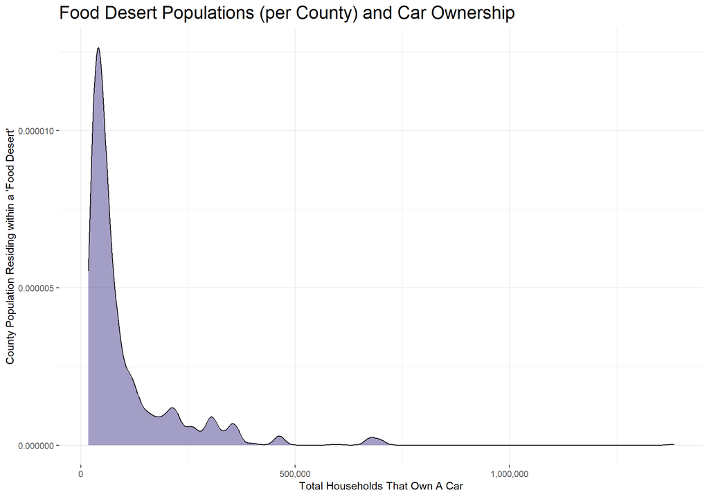

```r
#A density plot of the newly joined dataset is visualized.
ggplot(cjoined, aes(x=TotCars)) + geom_density(color="black", fill="darkslateblue", alpha = 0.5) + ylab("County Population Residing within a 'Food Desert'") + xlab('Total Households That Own A Car') + ggtitle("Food Desert Populations (per County) and Car Ownership") + theme(plot.title = element_text(size=18)) +scale_x_continuous(labels = scales::comma) +scale_y_continuous(labels = scales::comma)
```

Similar to previous figures, one would be hard pressed to leverage the transportation information, included within this data set and relayed by this visualization, to unethical ends.Very few, if any, novel inferences are hidden within this data set, as this data set is simply a depiction of the physical world (i.e. how many cars are owned per household, per county). Thus, not only is this visualization free of ethical concern, but the data collection process in itself was also ethically “clean” as the US Census made use of publicly available (anonmyized) vehicle registration logs, which are not at risk of being de-anonmyized .

### The Health Effects of Food Deserts

```r
#dataset with chronic diseases is loaded, with specific columns selected/excluded
chronic <- read.csv('chronic.csv', skip=2)
chronic <- chronic %>% select(X,X.1,X.4,X.5,X.6,X.8,X.9,X.10,X.11,X.12,X.13,X.14,X.15,X.16,X.17,X.18,X.19,X.20)
chronic <- chronic[-c(1),]

#dataset subsetted, rows deleted and index reset
colnames(chronic) <- chronic[1, ]
rownames(chronic) = NULL
chronic <- chronic[-c(1,2,3),]
rownames(chronic) = NULL

#Col Names formalized
names(chronic)=c("State","NAME", 'Arthritis',   'Asthma',   'Atrial Fibrillation',  'Cancer',   'Chronic Kidney Disease',   'COPD', 'Depression',   'Diabetes', 'Drug Abuse/Substance Abuse',   'HIV/AIDS', 'Heart Failure',        'Hyperlipidemia',   'Hypertension', 'Ischemic Heart Disease Osteoporosis',  'Schizophrenia/Other Psychotic Disorders',  'Stroke')


#Replacing blank spaces with NA's.
chronic$NAME[chronic$NAME=="  "] <- NA


chronic <- chronic %>%
  mutate(NAME = ifelse(is.na(NAME), State, NAME))


#Delete blank spaces
for (i in 1:3252){
  chronic[i,1] = trimws(chronic[i,1])
}

#Delete state names from county name column
for (i in 1:3252){
  if (chronic[i,1] %in% states){
    chronic <- chronic[-i,]
  }
}


rownames(chronic) = NULL

chronic <- chronic[, c("NAME","State", 'Arthritis', 'Asthma',   'Atrial Fibrillation',  'Chronic Kidney Disease',   'COPD',     'Diabetes', 'Heart Failure',        'Hyperlipidemia',   'Hypertension','Stroke')]

for (i in 1:1627){
  chronic[i,1] = trimws(chronic[i,1])
}


#chronic disease dataset merged with food desert population dataset
chjoined <- merge(chronic, totalpop, by = 'NAME', duplicateGeoms = FALSE)

rownames(chjoined) = NULL

chjoined[chjoined == "* "] <- NA


#Columns changed to numeric
chjoined$Pop <- as.numeric(chjoined$Pop)
chjoined$Arthritis <- as.numeric(chjoined$Arthritis)
chjoined$Asthma <- as.numeric(chjoined$Asthma)
chjoined$`Atrial Fibrillation` <- as.numeric(chjoined$`Atrial Fibrillation`)
chjoined$`Chronic Kidney Disease` <- as.numeric(chjoined$`Chronic Kidney Disease`)
chjoined$COPD <- as.numeric(chjoined$COPD)
chjoined$Diabetes <- as.numeric(chjoined$Diabetes)
chjoined$`Heart Failure` <- as.numeric(chjoined$`Heart Failure`)
chjoined$Hyperlipidemia <- as.numeric(chjoined$Hyperlipidemia)
chjoined$Hypertension <- as.numeric(chjoined$Hypertension)
chjoined$Stroke <- as.numeric(chjoined$Stroke)



#dataset subsetted for +10000 food desert populace only
chjoined <- chjoined[chjoined$Pop >=10000,]


#dataset pivotted ahead of facet wrap
pivot <- pivot_longer(chjoined, col = Arthritis : Stroke, names_to = "disease", values_to = "Prevelence")

pivot <- pivot[-c(4)]

pivot <- pivot %>% distinct(NAME, State, disease,Pop, .keep_all = TRUE)
pivot <- pivot %>% distinct(TotPop, disease, .keep_all = TRUE)
```

##### **Figure 9**

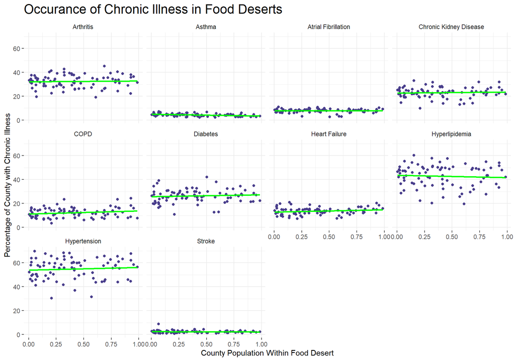

```r
#Facet wrap
ggplot(pivot, aes(x = TotPop, y = Prevelence)) + geom_point(color = "darkslateblue") + ylab("Percentage of County with Chronic Illness") + xlab('County Population Within Food Desert') + ggtitle("Occurance of Chronic Illness in Food Deserts") + theme(plot.title = element_text(size=18)) +scale_x_continuous(labels = scales::comma) +scale_y_continuous(labels = scales::comma) + facet_wrap(~disease) +geom_smooth(method="lm", color = "green", se = FALSE)
```

**Figure 9** above depicts a facet-wrap of a range of chronic illnesses, exhibited by comparing the percentage of the county that resides within a food desert on the X-Axis, and the percentage of a county’s populace that suffer from chronic illnesses on the Y-Axis. To formalize any correlation that may be present, a regression line is also plotted on each facet.

One is immediately struck by the lack of correlation in all facets, as all regression lines display as nearly horizontal.This reveals that the incidence of chronic illness in food deserts is not necessarily higher or lower than in non-food deserts, as if this were the case, a positive or negative correlation (respectively) would be exhibited.

While disappointing, this result is certainly not surprising. Foods with copious amounts of preservatives, as are found within food deserts, are not unhealthy in an absolute sense. Many preserved/canned foods do contain many nutrients that are more than capable of sustaining one’s self. It is only when such foods are compared to organic foods that a clear favorite in terms of “absolute health” arises.

That is to say, while one is always better off consuming organic foods regularly, engaging in a diet high in preservatives **may** result in the manifestation of chronic illnesses, **or it may not**. While one is certainly better off living outside of a food desert, the degree of unhealthiness inside a food desert does not surpass that which *may* be found in non-food deserts as well. This is due to the fact that “health” is a multifaceted phenomenon which can be decided by many variables such as one’s genetics, or access to affordable healthcare, rather than by one’s diet alone.

```r
#Obsesity dataset loaded
ob <- read.csv('obesity.csv')

#Key columns renamed
ob <- ob %>%
  rename(
    state  = State,
    NAME  = County
    )
names(ob)[7] = "mObesity"
names(ob)[8] = "fObesity"

#Obesity data set merged with total food desert population data set along two columns.
objoined <- merge(ob, totalpop, by=c("NAME","state"))

#key column renamed ahead of merge with shp file later
names(objoined)[2] = "STATE_NAME"
```

##### **Figure 10**

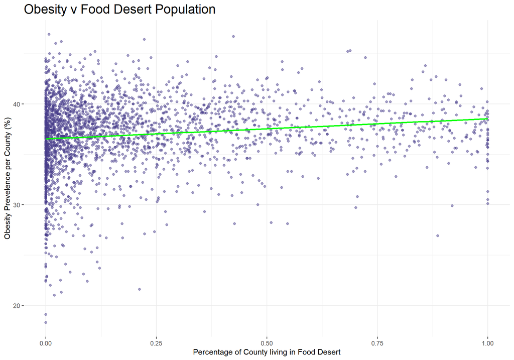

**Figure 10** places a spotlight on Obesity, a chronic illness that is often most associated with Food Deserts due to a high correlation existing between obesity and the nature of one’s diet. **Figure 10** proceeds by comparing the percentage of the county that resides within a food desert on the X-Axis, and the percentage of a county’s populace that suffer from obesity on the Y-Axis. Once again, to formalize any correlation that may be present, a regression line is also plotted.

Compared to **Figure 9**, one will immediately notice that a decidedly positive correlation exists between the percentage of a county living in a food desert, and the prevalence of obesity within that same county. Formally speaking, **Figure 10** reveals that as the percentage of of a county that lives within a food desert increases, so too does the prevalence of obesity.

One would be remiss if one did not have reservations about **Figure 10**. For instance, one will note that the positive correlation exhibited is not very large, a characteristic that primarily stems from the fact that although obesity prevalence certainly does increase as a county’s food desert population increases, *obesity is already relatively high when a county’s food desert population is zero*.

To truly understand why this might be, and the importance of context if one is to fully appreciate the limitations that accompany the multi-faceted subject of health data, one may proceed to **Figure 11**, which visualizes obesity rates across the entirety of the contiguous United States.

```r
#obesity dataset merged with shp file data
joinedob <- merge(shp, objoined, by = c("NAME","STATE_NAME"), duplicateGeoms = TRUE)

#Some NA values have appeared after the join. These values cannot be directly omitted as they will cause the eventual spatial visualization to return errors. Thus, the next for loop will seek these NA values out, and input '0' in place of the NA. This will not skew our data, as we are only interested in the counties WITH food desert populations, not counties with ZERO food desert populations. For our purposes, these values are still 'NA' as we are not analyzing them.

for (i in 1:3141){
  if (is.na(joinedob@data['mObesity'][[1]][[i]]) == TRUE){
    joinedob@data['mObesity'][[1]][[i]] = 0

  }
}
```

##### **Figure 11**

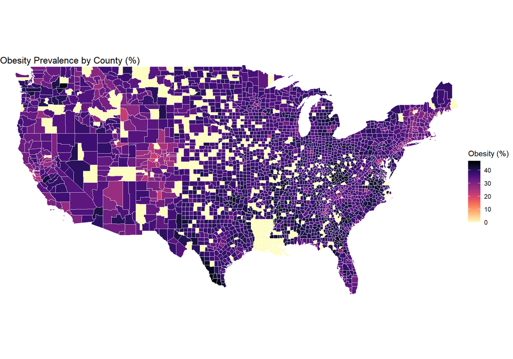

```r
#Obesity data visualized by county
joinedob9 <- st_as_sf(joinedob)

map <- ggplot(joinedob9) + geom_sf(aes(fill = mObesity), colour = "white") + xlim(-124, -69) + ylim(25, 48) + scale_fill_viridis(option="magma", direction = -1) + ggtitle("Obesity Prevalence by County (%)") +
  labs(fill = "Obesity (%)  ") +  theme_void()


map + theme_void()
```

**Figure 11** depicts the prevalence of Obesity at the county level across the entirety of the contiguous United States.

Looking at **Figure 11**, one will immediately notice that obesity is an issue that is far from being exclusive only to food desert counties, as it seems as if almost every county in the contiguous United States harbors significant populations who struggle with this chronic disease. This is not to say that food desert populations **do not** suffer from *increased* rates of obesity relative to counties with no food desert populations, however, amidst the backdrop of the United States healthcare system, a county which commands the highest healthcare costs per person ($12,318) amongst the OECD, and a country where millions cannot afford basic healthcare *due* to its high cost, chronic diseases are amplified across the board (Peterson par. 3).

As such, one should not discount the correlation exhibited in **Figure 10** on account of the fact that even counties with no food desert populations report high incidences of obesity, as within the context of the United States Healthcare system, this sad reality is to be expected.

Ethically speaking, there is much to discuss between **Figure 9**, **Figure 10**, and **Figure 11**. To begin, there is no reason to suspect that something unethical happened in the data collection process undertaken by the US Census, as all categories of chronic disease were listed according to their scientific names utilizing data curated by doctors and research scientists from the Center for Disease Control and Prevention (CDC). Thus, as field-specific experts had a direct hand in putting together the chronic disease data set utilized in the previous three visualizations, one can be assured that that data was collected ethically in a manner respectful to the afflicted.

A number of ethical issues presented themselves in my usage of the data. As mentioned previously, the data set on food desert population was released by the US Census at the census tract level. A census tract is a very small portion of land which contains, at most, only a few hundred to a few thousand citizens. The health data set, by contrast, reported health data at the county level. While kept separate, each data set sufficiently obfuscated the identities of their subjects, however, when joined together, it suddenly became possible to de-anonymize many health data points, as relatively rare chronic illnesses could be pinpointed to originate from within census tracts which themselves only contained a few hundred other healthy people. This is a serious problem, as it is likely that those who provided their health information to the CDC, who in turn provided such information to the US Census, did so under the assumption that they would remain anonymous. In my usage of the data, this assumption may be violated.

In terms of the visualizations created for **Figure 9**, **Figure 10**, and **Figure 11** based upon this data, I do not believe that any ethical boundaries were transgressed. Due to the new ethical prominence location indicators have gained due to the revelations described in the previous paragraph, I refrained from labeling specific data points with county or census tract names.

In general, it must be said that one must always seek to handle and interpret health data with empathy and compassion. In the context of spreadsheets and numbers, it is easy to forget that real lives are contained within each data point, each with unique struggles as an individual attempts to cope with his/her chronic illness. While **Figure 9**, **Figure 10**, and **Figure 11** were all very general, the uniqueness of each data point each visualization was summarizing was never forgotten.

### Concluding Remarks

A great many points of knowledge were uncovered in this rudimentary exploration of the phenomenon of food deserts in the contiguous United States.

For instance, in terms of where food deserts tend to be located in the contiguous United States, it was discovered that the South-West region of the United States is particularly inundated with counties with a high food desert population, not least because the sub-sovereign status of the Native Americans living within those counties necessitate that food distributors negotiate separate distribution contracts in those areas, something they are not willing to do (**Figure 3** and **Figure 4**).

In the American Mid-West, it was discovered that food deserts arise not due to esoteric legal agreements, but because it is more convenient for populations to travel distances greater than 1 MILE/10 MILES to get organic food, due to how highly integrated transportation infrastructure is within greater statistical areas (**Figure 5** and **Figure 6**).

With regards to further research, perhaps it would be useful to look at other countries with more robust health systems with no sub-sovereign indigenous populations, such that one may uncover the true reason that food deserts and their related health detriments manifest, beyond reasonings specific to the United States alone.

#### Bibliography

Bureau, US Census. “Urban and Rural.” Census.gov, 3 Oct. 2022, https://www.census.gov/programs-surveys/geography/guidance/geo-areas/urban-rural.html.

Kewenvoyouma, Jarod. “Doing Business with Tribal Governments: An Ultimate Guide: Kiva Institute.” KIVA Institute, LLC, 28 Sept. 2021, https://kivainstitute.com/doing-business-with-tribal-goverments/#:~:text=Any%20business%20that%20operates%20on,to%20work%20on%20tribal%20land.

Peterson, Peter G. “How Does the U.S. Healthcare System Compare to Other Countries?” Peter G. Peterson Foundation, 2021, https://www.pgpf.org/blog/2022/07/how-does-the-us-healthcare-system-compare-to-other-countries#:~:text=In%202021%2C%20the%20United%20States,capita%20across%20the%20OECD%20countries.

Shrider, Emily A. “Income and Poverty in the United States: 2020.” Census.gov, US Census, 9 June 2022, https://www.census.gov/library/publications/2021/demo/p60-273.html.

Sparks, Andrea L., et al. “Comparative Approaches to Measuring Food Access in Urban Areas.” Urban Studies, vol. 48, no. 8, 2010, pp. 1715–1737., https://doi.org/10.1177/0042098010375994.

US Census - Car Data. “Vehicle Inventory and Use Survey (VIUS).” Census.gov, US Census, 26 Aug. 2022, https://www.census.gov/programs-surveys/vius.html.

US Census - Indian. “American Indian and Alaska Native Data Links.” Census.gov, 16 Dec. 2021, https://www.census.gov/about/partners/cic/resources/data-links/aian.html.

US Census - OpenIntro. “United States Counties.” County Name/Total Population Data Set, 2010, https://www.openintro.org/data/?data=county_complete.

US Census. “Census Bureau Releases Estimates of Undercount and Overcount in the 2020 Census.” Census.gov, 10 Mar. 2022, https://www.census.gov/newsroom/press-releases/2022/2020-census-estimates-of-undercount-and-overcount.html.

USDA - Census. “Food Access Research Atlas.” USDA ERS - Food Access Research Atlas DATASET, 2021, https://www.ers.usda.gov/data-products/food-access-research-atlas/.

Ver Ploeg, Michele, et al. “Measuring Food Access and Food Deserts for Policy Purposes.” Applied Economic Perspectives and Policy, vol. 37, no. 2, 2014, pp. 205–225., https://doi.org/10.1093/aepp/ppu035.